# Introduction to Metabolomics

Jake Sauter

2/19/2021

## **Loading Data**

```r
getwd()
```

```
## [1] "/home/x1/Documents/Weill_Cornell/Functional_Interpretation/metabolomics/homework_1/R"
```

```r
library(magrittr)
data_dir <- "/home/x1/Documents/Weill_Cornell/Functional_Interpretation/metabolomics/homework_1/data/"
data_filename <- list.files(data_dir, "Simulated_metabolomics_data.RData",
                            full.names = TRUE)
data_filename %<>% normalizePath(mustWork=TRUE)
data_env <- new.env()
load(data_filename, envir = data_env)
ls(data_env)
```

```
## [1] "annotations" "dat"         "gender"
```

We see that there are three objects loaded into the `data_env` environment from this data file. Let us first check the type and dimensionality of each of these new variables.

```r
str(data_env$gender)
```

```
##  int [1:906] 1 1 2 1 1 2 2 1 1 2 ...
```

```r
str(data_env$annotations)
```

```
## Classes 'data.table' and 'data.frame':   335 obs. of  4 variables:
##  $ name         : chr  "M20675" "M34400" "M33228" "M35186" ...
##  $ Super_pathway: chr  "Carbohydrate" "Xenobiotics" "Lipid" "Lipid" ...
##  $ Sub_pathway  : chr  "Glycolysis, Gluconeogenesis, and Pyruvate Metabolism" "Xanthine Metabolism" "Lysolipid" "Lysolipid" ...
##  $ Label        : chr  "1,5-anhydroglucitol (1,5-AG)" "1,7-dimethylurate" "1-arachidonoylglycerophosphocholine (20:4n6)*" "1-arachidonoylglycerophosphoethanolamine*" ...
##  - attr(*, ".internal.selfref")=<externalptr>
```

```r
str(data_env$dat)
```

```
##  num [1:906, 1:335] 0.838 1.566 2.475 1.874 1.154 ...
##  - attr(*, "dimnames")=List of 2
##   ..$ : NULL
##   ..$ : chr [1:335] "M20675" "M34400" "M33228" "M35186" ...
##  - attr(*, "scaled:center")= Named num [1:335] -0.01605 -0.45303 -0.00649 0.0208 0.00487 ...
##   ..- attr(*, "names")= chr [1:335] "M20675" "M34400" "M33228" "M35186" ...
##  - attr(*, "scaled:scale")= Named num [1:335] 0.453 1.019 0.525 0.377 0.444 ...
##   ..- attr(*, "names")= chr [1:335] "M20675" "M34400" "M33228" "M35186" ...
```

### **Checking Data Quality**

We will first check overall metabolite measurement levels between the samples to ensure that there are no **batch effects** or experimental abnormalities. We note that it is commonly accepted to **log** biological data before interpretation as this usually results in **normally distributed** data.

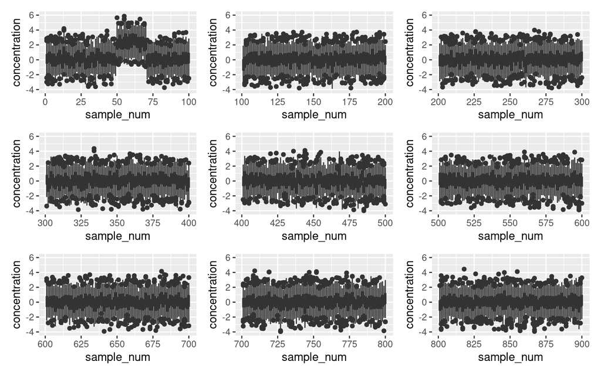

```r
df <-
  data_env %>%
  .$dat %>%
  log() %>%
  as.data.frame() %>%
  mutate(sample_num = row_number()) %>%
  pivot_longer(-c(sample_num),
               names_to='metabolite', values_to="concentration")

plot_list <- vector('list', 9)
for (group_num in 1:9) {
  first_sample <- 1 + (100 * (group_num - 1))
  last_sample <- 100 * (group_num - 1) + 100

  plot_list[[group_num]] <- df %>%
    filter(sample_num >= first_sample,
           sample_num <= last_sample) %>%
    ggplot() +
      geom_boxplot(aes(x=sample_num,
                       y=concentration,
                       group=sample_num)) +
      ylim(c(-4, 6))
}

(plot_list[[1]] + plot_list[[2]] + plot_list[[3]]) /
(plot_list[[4]] + plot_list[[5]] + plot_list[[6]]) /
(plot_list[[7]] + plot_list[[8]] + plot_list[[9]])
```

**What do you observe? What possible reasons could there be? Tip: Omics data should always be logged before visualization.**

Let’s more closely visualize those samples that appear to have higher measurement levels all-around on all of the studied metabolites.

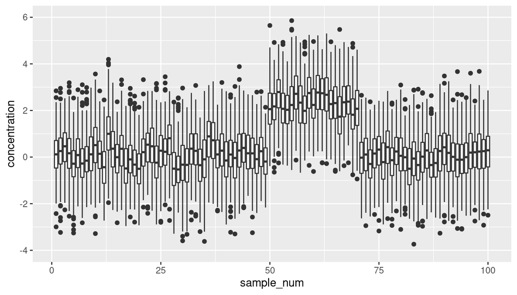

```r
plot_list[[1]]
```

We see here that there is a specific set of samples that shows increased concentration measurements relative to all other experiments seen in this dataset.

### **Quotient Normalization**

**Steps for Quotient Normalization**:

- Calculate the median sample
- For Each Sample:
  - Calculate the quotient of every metabolite concentration level with respect to the median sample
  - Determine the median metabolite quotient (*MMQ*)
  - Divide the concentration of all metabolites in the sample by the *MMQ*

```r
median_sample <- apply(data_env$dat, 2, median)
normalized_dat <- data_env$dat

for (i in 1:nrow(normalized_dat)) {
  quotient <- data_env$dat[i,] / median_sample
  median_quotient <- median(quotient)
  normalized_dat[i,] = data_env$dat[i,] / median_quotient
}
```

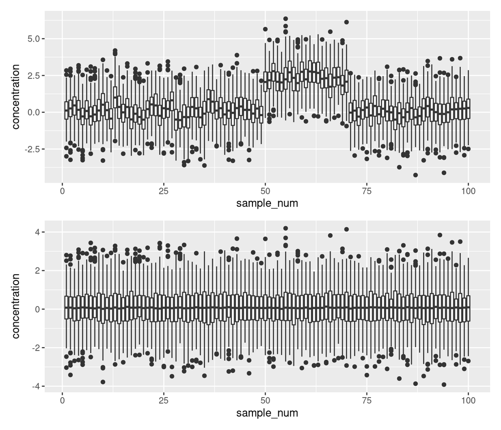

```r
library(tidyverse)
library(patchwork)

df_before <-
  data_env %>%
  .$dat %>%
  .[1:100, ] %>%
  log() %>%
  as.data.frame() %>%
  mutate(sample_num = row_number()) %>%
  pivot_longer(-c(sample_num),
               names_to='metabolite', values_to="concentration")
p1 <-
  df_before %>%
  ggplot() +
        geom_boxplot(aes(x=sample_num,
                         y=concentration,
                         group=sample_num))

df_after <-
  normalized_dat %>%
  .[1:100, ] %>%
  log() %>%
  as.data.frame() %>%
  mutate(sample_num = row_number()) %>%
  pivot_longer(-c(sample_num),
               names_to='metabolite', values_to="concentration")

p2 <-
  df_after %>%
  ggplot() +
        geom_boxplot(aes(x=sample_num,
                         y=concentration,
                         group=sample_num))

p1 / p2
```

## **Phenotype association**

### **Male vs Female**

We will first analyze the metabolite differences between males and females, using t-tests.

```r
?t.test
```

For each METABOLITE, we will be performing a t-test between the expression profiles of groups split between sex

We will be performing these test on the **normalized**, and **logged** data.

```r
log_norm_dat <- log(normalized_dat)
```

Now we can perform a `t.test` for each metabolite

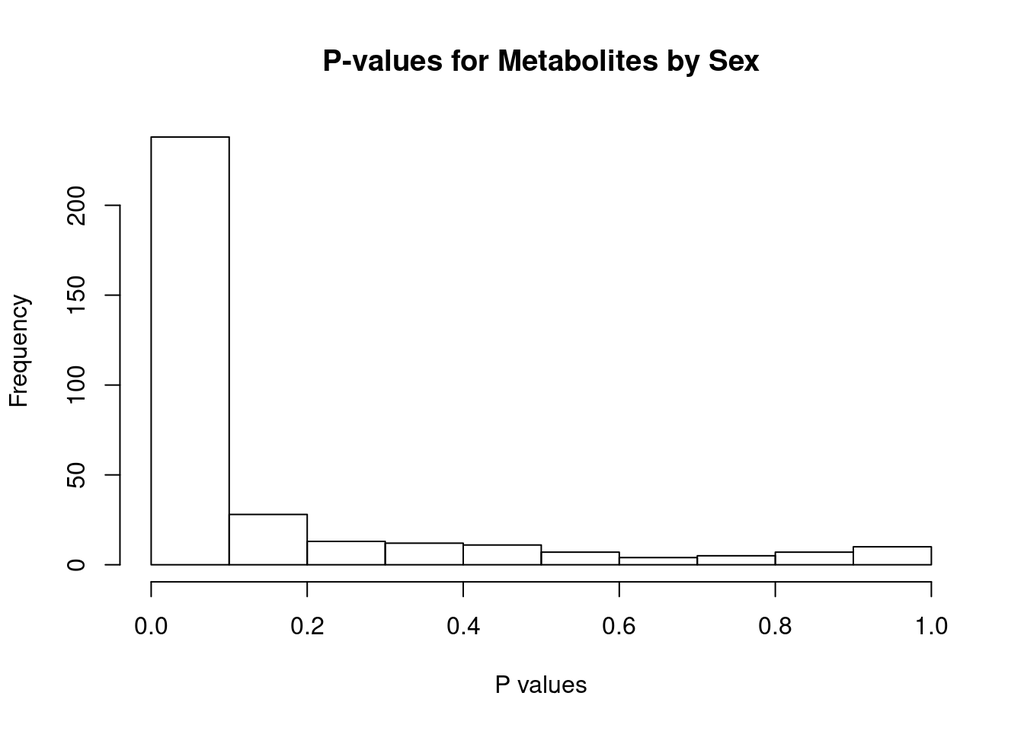

```r
metabolites <- colnames(log_norm_dat)

p_vals <- vector('double', length(metabolites))
names(p_vals) <- metabolites

for (metabolite in metabolites) {
  male   <- log_norm_dat[data_env$gender==1, metabolite]
  female <- log_norm_dat[data_env$gender==2, metabolite]
  p_vals[metabolite] <- t.test(male, female)$p.value
}

hist(p_vals,
     main='P-values for Metabolites by Sex',
     xlab='P values')
```

**What do you observe? Perform multiple testing correction with a method and α of your choice.**

Below we can see the resultant pvalues as well as their adjusted counterparts.

```r
?p.adjust
```

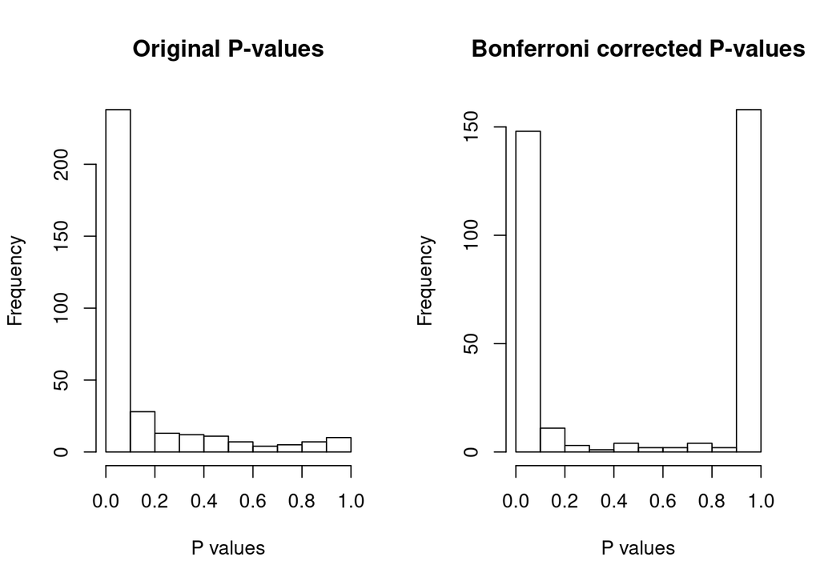

```r
adj_p_vals <- p.adjust(p_vals, 'bonferroni')

par(mfrow = c(1, 2))

hist(p_vals,
     main='Original P-values',
     xlab='P values')

adj_p_vals <- p.adjust(p_vals, 'bonferroni')
hist(adj_p_vals,
     main='Bonferroni corrected P-values',
     xlab='P values')
```

**How many metabolites are significantly associated with gender before and after multiple testing correction?**

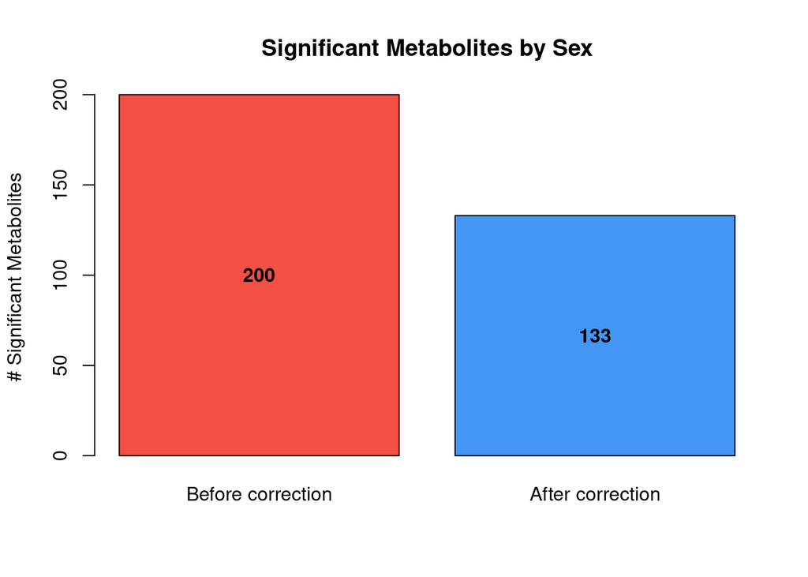

```r
before <- length(which(p_vals < 0.01))
after <- length(which(adj_p_vals < 0.01))
bp <- barplot(c(before, after),
        main = "Significant Metabolites by Sex",
        ylab = "# Significant Metabolites",
        names.arg = c('Before correction', 'After correction'),
        col = c("#f45044", "#4496f4"))

text(bp, c(before,after)/2, labels = c(before,after), font = 2)
```

**Which 10 metabolites are most significantly associated with gender? Which pathways do these metabolites belong to?**

```r
library(knitr)
top_ten <- names(sort(adj_p_vals)[1:10])

data_env$annotations %>%
  as.data.frame() %>%
  filter(name %in% top_ten) %>%
  kable()
```

| name | Super_pathway | Sub_pathway | Label |
| --- | --- | --- | --- |
| M33968 | Lipid | Medium Chain Fatty Acid | 5-dodecenoate (12:1n7) |
| M37190 | Lipid | Steroid | 5alpha-androstan-3beta,17beta-diol disulfate |
| M27718 | Amino Acid | Creatine Metabolism | creatine |
| M34456 | Peptide | Gamma-glutamyl Amino Acid | gamma-glutamylisoleucine* |
| M18369 | Peptide | Gamma-glutamyl Amino Acid | gamma-glutamylleucine |
| M1125 | Amino Acid | Leucine, Isoleucine and Valine Metabolism | isoleucine |
| M32418 | Lipid | Long Chain Fatty Acid | myristoleate (14:1n5) |
| M43488 | Peptide | Dipeptide Derivative | N-acetylcarnosine |
| M33447 | Lipid | Long Chain Fatty Acid | palmitoleate (16:1n7) |
| M32672 | Amino Acid | Glutamate Metabolism | pyroglutamine* |

**Visualize the differences between male and female for the top hit.**

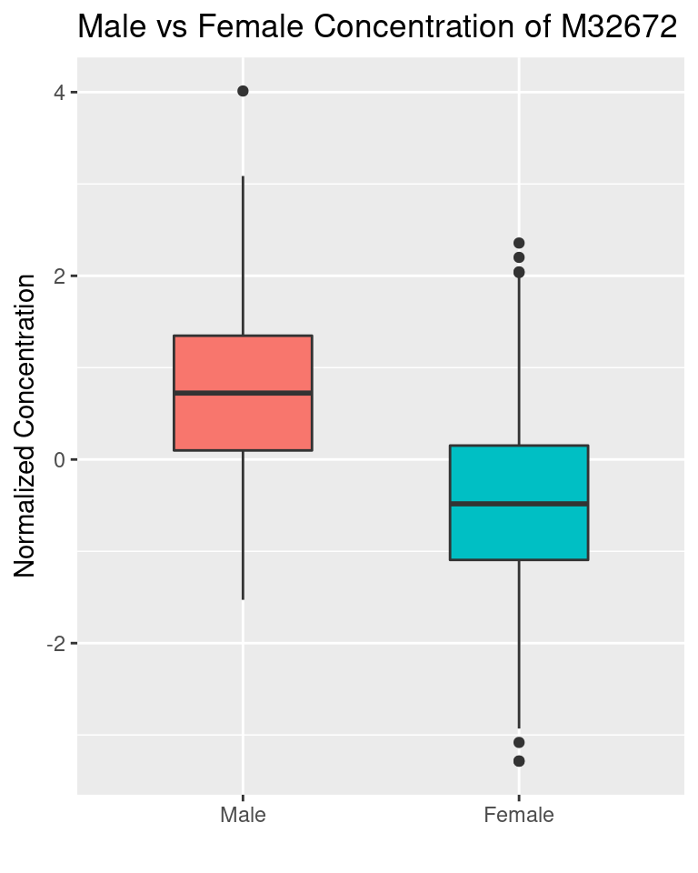

```r
top_hit <- names(sort(adj_p_vals)[1])

male <- log_norm_dat[data_env$gender==1, top_hit]
female <- log_norm_dat[data_env$gender==2, top_hit]

male <- c(male, rep(NA, length(female) - length(male)))

df <-
  data.frame(Male=male,
             Female=female) %>%
  mutate(index = row_number()) %>%
  pivot_longer(-c(index),
               names_to='sex', values_to="concentration") %>%
  mutate(sex = factor(sex, levels = c('Male', 'Female')))



df %>%
  ggplot() +
  geom_boxplot(aes(x=sex,
                   y=concentration,
                   fill=sex),
                width = 0.5
               ) +
  theme(legend.position = "none") +
  labs(title=paste('Male vs Female Concentration of', top_hit)) +
  xlab("") +
  ylab("Normalized Concentration")
```

## **Gaussian graphical model (GGM)**

### **Partial Correlations and P-Values**

We will use the `ppcor` package to calculate the partial correlations between all of the measured metabolites in our samples.

```r
pcor <- ppcor::pcor(log_norm_dat)
names(pcor)
```

```
## [1] "estimate"  "p.value"   "statistic" "n"         "gp"        "method"
```

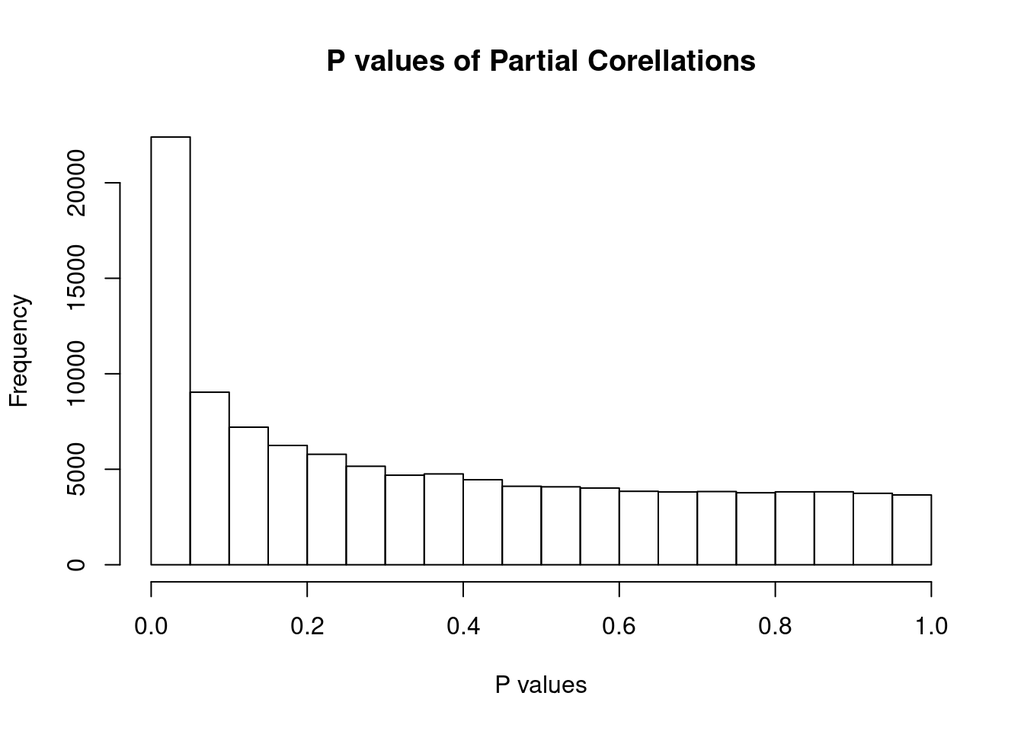

```r
p_vals <- pcor$p.value
hist(p_vals,
     main = "P values of Partial Corellations",
     xlab = "P values")
```

### Bonferroni Correction

**Perform multiple testing correction with Bonferroni correction. When calculating the number of tests, remember that a correlation matrix is symmetric and the diagonal does not count (calculate how many values there are in a correlation matrix). Set all insignificant values and the in the partial correlation matrix to zero.**

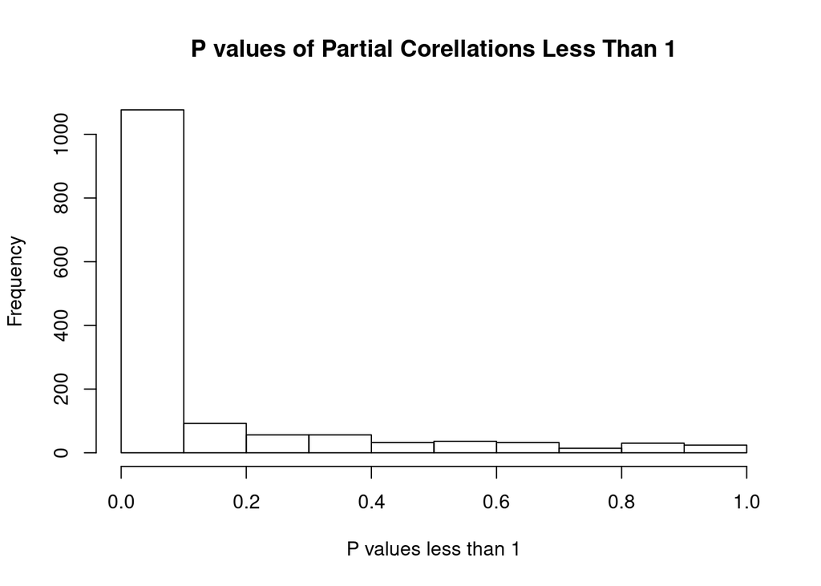

```r
n <- ncol(log_norm_dat)
n_tests <- (n*(n-1))/2

adj_p_vals <- p_vals * n_tests
adj_p_vals[adj_p_vals > 1] = 1

hist(adj_p_vals[adj_p_vals < 1],
     main = "P values of Partial Corellations Less Than 1",
     xlab = "P values less than 1")
```

```r
adj_mat <- pcor$estimate
adj_mat[adj_p_vals > 0.01] = 0

for (i in 1:nrow(adj_mat)) {
  adj_mat[i, i] = 0
}

colnames(adj_mat) <- colnames(log_norm_dat)
rownames(adj_mat) <- colnames(log_norm_dat)
```

### **Visualizing the GGM**

**This matrix is the adjacency matrix of the underlying Gaussian graphical model. Visualize the network using the igraph package (tip: graph.adjacency function).**

```r
# Assemble the non-zero matrix
nonzero_metabolites <- c()

for (metabolite in colnames(adj_mat)) {
  if (any(adj_mat[metabolite, ] != 0) |
      any(adj_mat[, metabolite] != 0)) {
     nonzero_metabolites %<>% append(metabolite)
  }
}

adj_mat <- adj_mat[nonzero_metabolites, nonzero_metabolites]
```

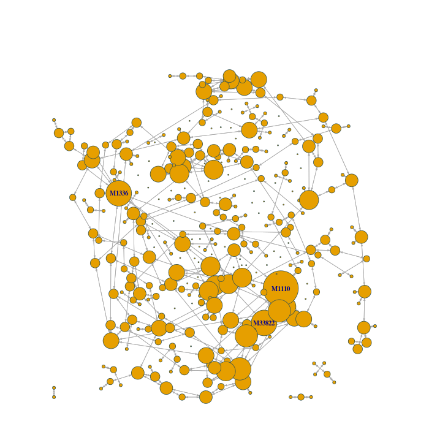

```r
library(igraph)

graph <- graph.adjacency(adj_mat,
                         weighted = TRUE,
                         diag = FALSE,
                         mode = 'directed')

V(graph)$size <- degree(graph)
V(graph)$name[degree(graph) < 12] <- ""


# png('graph.png',
#     width  = 700,
#     height = 700)

par(mai=c(0,0,1,0))

plot(graph,
     layout=layout_with_dh(graph),
     edge.arrow.size = 0.3,
     vertex.label.font = 2,
     vertex.label.cex = 0.9,
     vertex.frame.color = 'darkslategrey')

# dev.off()
```